# Statistik mit R

7. Oktober 2017

## Nomenklatur

## Population vs. Stichprobe

Stellt euch vor, ihr möchtet herausfinden, bei welchem mittlerem Alter Patienten mit Parkinson diagnostiziert werden.

- Sämtliche Menschen weltweit mit einer Parkinson-Diagnose stellen die Grundgesamtheit oder auch Population dar.
- Alle Menschen, die euch für eure Studie zur Verfügung stehen, stellen die Stichprobe dar.

## Parameter vs. Statistik

- Eigenschaften der Population, wie z.B. das mittlere Diagnose-Alter, bezeichnet man als Parameter.
- Werte, die ihr von eurer Stichprobe berechnet, bezeichnet man als Statistik. Bei einem guten Design erlauben Statistiken Rückschlüsse auf die Parameter der zugrundeliegende Population.
- Parameter werden mit griechischen Buchstaben abgekürzt, Statistiken mit lateinischen.
- \(\mu\) bzw. \(\overline{x}\) bezeichnen das arithmetische Mittel.
- \(\sigma\) bzw. s bezeichnen die Standardabweichung.

## Deskriptive Statistik

## summarise()

`summarise()` nimmt (einen gruppierten) Datensatz und berechnet daraus zusammenfassende Werte:

- Zentrale Tendenzen (Arithmetisches Mittel, Median, Modus).
- Verteilungsmaße (Standardfehler, Varianz).
- Konfidenzintervalle
- …

```r
Diameter <- read_csv("../Exercises/Diameter/Diameter.csv")

head(Diameter)
```

```
## # A tibble: 6 x 6
##   `Length [um]` Measured Group CatID          Species
##           <dbl>    <chr> <int> <chr>            <chr>
## 1        421.21 Diameter     1 16758 Acinonyx.jubatus
## 2        399.62 Diameter     1 16758 Acinonyx.jubatus
## 3        446.16 Diameter     2 16758 Acinonyx.jubatus
## 4        350.64 Diameter     2 16758 Acinonyx.jubatus
## 5        411.32 Diameter     3 16758 Acinonyx.jubatus
## 6        316.19 Diameter     3 16758 Acinonyx.jubatus
## # ... with 1 more variables: File <chr>
```

## Zentrale Tendenz

Gegebenenfalls gruppiert man seine Daten und fasst diese dann zusammen.

```r
DiameterAnalysis <- Diameter %>%
  group_by(Species, CatID, Group) %>%
  summarise(Count = n(),
            Mean_Diameter = mean(`Length [um]`))
```

```r
head(DiameterAnalysis)
```

```
## # A tibble: 6 x 5
## # Groups:   Species, CatID [1]
##            Species CatID Group Count Mean_Diameter
##              <chr> <chr> <int> <int>         <dbl>
## 1 Acinonyx.jubatus 16758     1     2       410.415
## 2 Acinonyx.jubatus 16758     2     2       398.400
## 3 Acinonyx.jubatus 16758     3     2       363.755
## 4 Acinonyx.jubatus 16758     4     2       350.160
## 5 Acinonyx.jubatus 16758     5     2       345.915
## 6 Acinonyx.jubatus 16758     6     2       394.865
```

Außerdem möglich:

- `median()`: Der Median.
- `DescTools::Mode()`: Der häufigste Wert (sinnvoll für kategorische Werte).

## Variation

```r
DiameterAnalysis <- Diameter %>%
  group_by(Species, CatID, Group) %>%
  summarise(Count = n(),
            Mean_Diameter = mean(`Length [um]`),
            SD_Diameter = sd(`Length [um]`))
```

`var()` geht natürlich auch.

```r
head(DiameterAnalysis)
```

```
## # A tibble: 6 x 6
## # Groups:   Species, CatID [1]
##            Species CatID Group Count Mean_Diameter SD_Diameter
##              <chr> <chr> <int> <int>         <dbl>       <dbl>
## 1 Acinonyx.jubatus 16758     1     2       410.415    15.26644
## 2 Acinonyx.jubatus 16758     2     2       398.400    67.54284
## 3 Acinonyx.jubatus 16758     3     2       363.755    67.26707
## 4 Acinonyx.jubatus 16758     4     2       350.160    71.91276
## 5 Acinonyx.jubatus 16758     5     2       345.915    69.98236
## 6 Acinonyx.jubatus 16758     6     2       394.865     5.69221
```

## Statistische Tests

## Doch zuvor etwas Grundsätzliches

Die Statistik sollte nicht erst **nach** einem Experiment beginnen, sondern bereits **davor**.

- Stelle eine biologische Fragestellung auf
- Formuliere eine biologische Nullhypothese
- Formuliere eine statistische Nullhypothese
- Stelle heraus, welche Variablen für das Experiment von Bedeutung sind und welchen Typus sie haben.
- Designe das Experiment!
- Wähle einen statistischen Test
- Führe das Experiment durch
- Überprüfe deine Messergebnisse
- Führe den statistischen Test durch

Erst im letzten Schritt geht es darum, den statistischen Test auf seine Daten anzuwenden und die Ergebnisse zu interpretieren.

- Ist der Befund überhaupt biologisch relevant?

## Null- und Alternativhypothese

Vor einem Test stellt man immer eine Null- und eine Alternativ-Hypothese auf (damit überhaupt klar ist, worauf man testet).

- *H<sub>0</sub>*: Da man i.d.R. immer auf einen Unterschied testet, und die Null-Hypothese das Gegenteil darstellt, ist H<sub>0</sub> die Hypothese, dass es keinen Unterschied zwischen zwei Gruppen gibt / zwei Variablen unabhängig voneinander sind / usw.
- *H<sub>A</sub>*: Die Alternativ-Hypothese ist die gegenteilige Annahme der Null-Hypothese: Es gibt einen Unterschied zwischen zwei Gruppen oder zwei Variablen sind abhängig voneinander.
- Der *p-Value* gibt die Wahrscheinlichkeit an, dass die Null-Hypothese zutrifft. Bei weniger als 5% verwirft man i.d.R. die Null-Hypothese und akzeptiert stattdessen die Alternativ-Hypothese.

## Den richtigen statistischen Test finden

- Welcher Variablentyp soll getestet werden? **Nominal**, **Ordinal** oder **Metrisch**
- Wie viele Gruppen sollen miteinander verglichen werden?
- Sind die Beobachtungen unabhängig voneinander?
- Falls die Variablen metrisch sind: Sind die Daten **normalverteilt**? Sind die Daten **homoskedastisch** (gleiche SD)? Sind die zu vergleichenden Gruppen **gleich groß**?

## Nominale Variablen testen

## Die Idee

Nominale Datenreihen bestehen nicht aus Zahlen, deren Mittelwert und Variation man testen kann. Stattdessen kann man nur die Häufigkeit jedes Werts mit einer erwarteten Häufigkeit vergleichen. Es wird unterschieden zwischen **Goodness-of-Fit-Tests** und **Independence-Tests**.

## Goodness-of-Fit Tests

Testen eine beobachtete Häufigkeitsverteilung mit einer hypothetischen.

- Exact Test for Goodness-of-Fit (<1000 Beobachtungen)
- \(\chi^2\)-Test (>1000 Beobachtungen)

## Zunächst muss eine Kontingenztabelle erstellt werden

```r
library(NHANES)

ContingencyTable <- xtabs(~ Gender, NHANES)
ContingencyTable
```

```
## Gender
## female   male
##   5020   4980
```

```r
prop.table(ContingencyTable)
```

```
## Gender
## female   male
##  0.502  0.498
```

## Excact Binomial Test for Goodness-of-Fit

Gut geeignet für Datensätze mit weniger als 1000 Beobachtungen und nur zwei Ausprägungen.

```r
binom.test(ContingencyTable, p = 0.5)
```

```
##
##  Exact binomial test
##
## data:  ContingencyTable
## number of successes = 5020, number of trials = 10000, p-value =
## 0.6965
## alternative hypothesis: true probability of success is not equal to 0.5
## 95 percent confidence interval:
##  0.4921509 0.5118480
## sample estimates:
## probability of success
##                  0.502
```

## \(\chi^2\)-Test for Goodness-of-Fit

Für viele Beobachtungen und zwei oder mehr Ausprägungen.

```r
chisq.test(ContingencyTable, p = c(0.5, 0.5))
```

```
##
##  Chi-squared test for given probabilities
##
## data:  ContingencyTable
## X-squared = 0.16, df = 1, p-value = 0.6892
```

```r
ContingencyTable <- xtabs(~ Education, NHANES)
ContingencyTable
```

```
## Education
##      8th Grade 9 - 11th Grade    High School   Some College   College Grad
##            451            888           1517           2267           2098
```

```r
chisq.test(ContingencyTable, p = c(0.06, 0.12, 0.21, 0.31, 0.30))
```

```
##
##  Chi-squared test for given probabilities
##
## data:  ContingencyTable
## X-squared = 3.7751, df = 4, p-value = 0.4373
```

## Independence-Tests

Testet, ob zwei Variablen unabhängig voneiandner sind.

- Fisher's exact Test.
- \(\chi^2\)-Test for Independence.

## Kontingenztabelle erstellen

```r
ContingencyTable <- xtabs(~ Gender + Diabetes, NHANES)
ContingencyTable
```

```
##         Diabetes
## Gender     No  Yes
##   female 4592  357
##   male   4506  403
```

```r
prop.table(ContingencyTable)
```

```
##         Diabetes
## Gender           No        Yes
##   female 0.46581457 0.03621424
##   male   0.45709069 0.04088050
```

## Independence-Test durchführen

```r
fisher.test(ContingencyTable)
```

```
##
##  Fisher's Exact Test for Count Data
##
## data:  ContingencyTable
## p-value = 0.06439
## alternative hypothesis: true odds ratio is not equal to 1
## 95 percent confidence interval:
##  0.9891749 1.3382497
## sample estimates:
## odds ratio
##   1.150379
```

```r
chisq.test(ContingencyTable)
```

```
##
##  Pearson's Chi-squared test with Yates' continuity correction
##
## data:  ContingencyTable
## X-squared = 3.2964, df = 1, p-value = 0.06943
```

```r
chisq.test(ContingencyTable, correct = FALSE)
```

```
##
##  Pearson's Chi-squared test
##
## data:  ContingencyTable
## X-squared = 3.4349, df = 1, p-value = 0.06383
```

## Annahmen

Der \(\chi^2\)-Test hat zwei Annahmen an die Daten:

- Keine Zelle darf den Wert 0 enthalten.
- Mindestens 80% der Zellen müssen einen Wert >= 5 haben.
- Trifft eine der Annahmen nicht zu, kann man eine Yates-Korrektur hinzufügen oder man nimmt den Fisher-Test.

## Mosaikplots

Kontingenztabellen kann man in Mosaikplots darstellen. Allerdings verlieren diese schnell ihre Übersichtlichkeit.

```r
ContingencyTable <- xtabs(~ Gender + Education + Diabetes, NHANES)
ContingencyTable
```

```
## , , Diabetes = No
##
##         Education
## Gender   8th Grade 9 - 11th Grade High School Some College College Grad
##   female       163            352         684         1085         1048
##   male         188            429         668          954          906
##
## , , Diabetes = Yes
##
##         Education
## Gender   8th Grade 9 - 11th Grade High School Some College College Grad
##   female        46             48          86          112           51
##   male          54             57          79          116           93
```

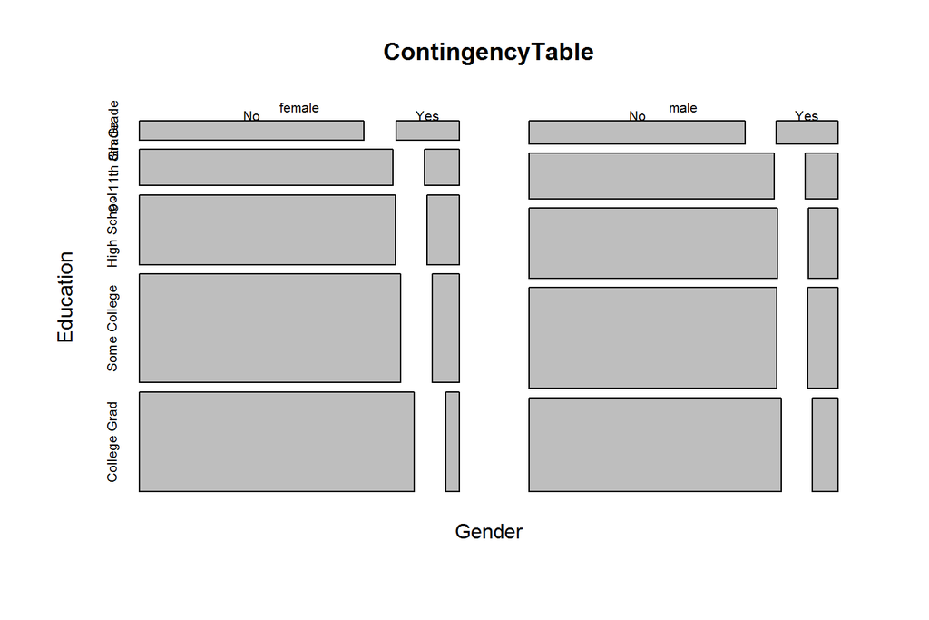

```r
mosaicplot(ContingencyTable)
```

## Mosaikplots in ggplot2

Auch `ggplot2` bietet durch das Erweiterungspaket `ggmosaic` die Möglichkeit, Mosaikplots zu erstellen.

Wenn es interessiert: [ggmosaic](https://cran.r-project.org/web/packages/ggmosaic/vignettes/ggmosaic.html)

## Metrische Variablen testen

## Annahmen

Die meisten Tests für metrische Variablen sind parametrisch und stellen daher Anforderungen an die zu untersuchenden Daten:

- Die Daten müssen **normalverteilt** sein.
- Die Daten müssen **homoskedastisch** sein, also die gleiche Standardabweichung besitzen.
- Die Beobachtungen müssen unabhängig voneinander sein.
- Die zu vergleichenden Gruppen müssen gleich groß sein.

## Was tun, wenn die Daten nicht passen?

- Man wählt einen nicht-parametrischen Test.

## Der Datensatz

```r
head(PlantGrowth)
```

```
##   weight group
## 1   4.17  ctrl
## 2   5.58  ctrl
## 3   5.18  ctrl
## 4   6.11  ctrl
## 5   4.50  ctrl
## 6   4.61  ctrl
```

## Normalität

Durch Histogramm zu erkennen oder mit einem Test wie dem Shapiro-Wilk-Test.

- H<sub>0</sub>, dass die Daten normalverteilt sind.

```r
shapiro.test(PlantGrowth$weight)
```

```
##
##  Shapiro-Wilk normality test
##
## data:  PlantGrowth$weight
## W = 0.98268, p-value = 0.8915
```

## Standardfehler

Der **Standardfehler** ist ein Maß für die Streuung **zwischen** den Stichproben.

\[ \frac{\sigma}{\sqrt{n}} \]

- \(\sigma\) ist die Standardabweichung der Grundgesamtheit und muss von der Stichprobe geschätzt werden (\(s\)).
- \(n\) ist der Stichprobenumfang.

## t-Tests

t-Tests überprüfen, wie viele Standardfehler der Stichprobenmittelwert von einem Erwartungswert abweicht.

- Als Ergebnis erhält man eine sogenannte t-Statistik.

\[ t = \frac{\overline{X} - \mu}{\frac{\sigma}{\sqrt{n}}} \]

## t-Verteilung

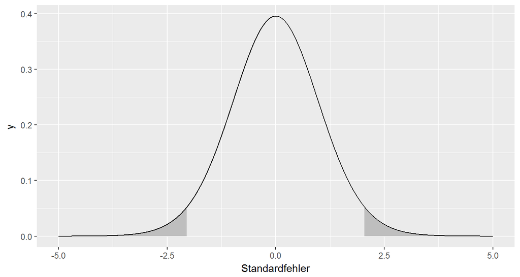

## One-Sample t-Test

\[ \frac{\overline{X} - \mu}{\frac{\sigma}{\sqrt{n}}} \]

```r
(5.073 - 4.85) / (0.7012 / sqrt(30))
```

```
## [1] 1.741901
```

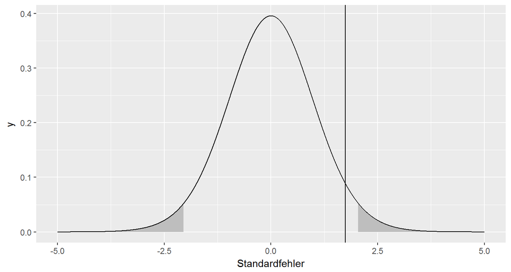

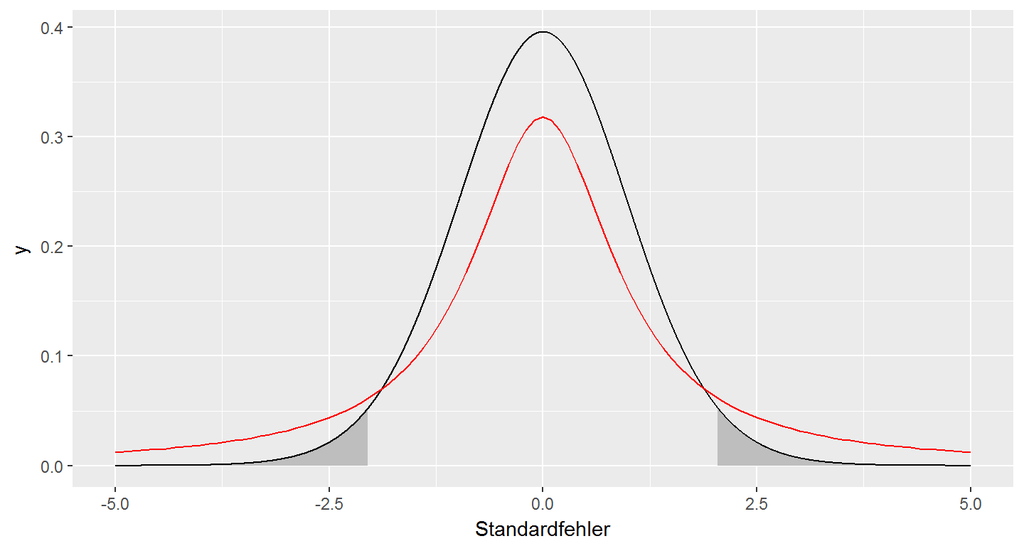

```r
t.test(PlantGrowth$weight, mu = 4.85)
```

```
##
##  One Sample t-test
##
## data:  PlantGrowth$weight
## t = 1.7419, df = 29, p-value = 0.09212
## alternative hypothesis: true mean is not equal to 4.85
## 95 percent confidence interval:
##  4.811171 5.334829
## sample estimates:
## mean of x
##     5.073
```

## Alternativen

Alternativ kann man testen, ob der Beobachtete Mittelwert höher oder geringer ist als der vorgegebene (einseitiger Test).

```r
t.test(PlantGrowth$weight, mu = 4.85, alternative = "less")
```

```
##
##  One Sample t-test
##
## data:  PlantGrowth$weight
## t = 1.7419, df = 29, p-value = 0.9539
## alternative hypothesis: true mean is less than 4.85
## 95 percent confidence interval:
##      -Inf 5.290521
## sample estimates:
## mean of x
##     5.073
```

```r
t.test(PlantGrowth$weight, mu = 4.85, alternative = "greater")
```

```
##
##  One Sample t-test
##
## data:  PlantGrowth$weight
## t = 1.7419, df = 29, p-value = 0.04606
## alternative hypothesis: true mean is greater than 4.85
## 95 percent confidence interval:
##  4.855479      Inf
## sample estimates:
## mean of x
##     5.073
```

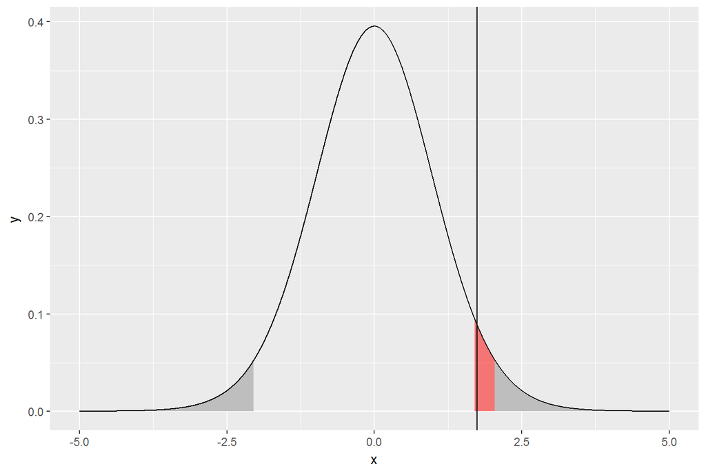

## Two-Sample t-Test

Häufiger möchte man eine metrische Variable zwischen zwei Gruppen miteinander vergleichen.

## Varianzgleichheit

Mithilfe des Bartlett-Tests kann man die Varianzgleichheit zweier oder mehrerer Gruppen überprüfen.

- H<sub>0</sub>, dass die Gruppen die gleiche Varianz haben.

```r
bartlett.test(weight ~ group, PlantGrowth)
```

```
##
##  Bartlett test of homogeneity of variances
##
## data:  weight by group
## Bartlett's K-squared = 2.8786, df = 2, p-value = 0.2371
```

## Der Test

Für den Two-Sample t-Test wählt man ebenfalls `t.test`, benutzt allerdings das formula-Interface der Funktion.

```r
t.test(weight ~ group, PlantGrowth, var.equal = TRUE,
       subset = group != "trt2")
```

```
##
##  Two Sample t-test
##
## data:  weight by group
## t = 1.1913, df = 18, p-value = 0.249
## alternative hypothesis: true difference in means is not equal to 0
## 95 percent confidence interval:
##  -0.2833003  1.0253003
## sample estimates:
## mean in group ctrl mean in group trt1
##              5.032              4.661
```

## Welch Two Sample-t-Test

Sind die Varianzen in den beiden Gruppen unterschiedlichen, unbekannt oder sind die Stichprobengrößer deutlich kleiner als 30, wählt man den Welch two-sample T-Test.

```r
t.test(weight ~ group, PlantGrowth, var.equal = FALSE,
       subset = group != "trt2")
```

```
##
##  Welch Two Sample t-test
##
## data:  weight by group
## t = 1.1913, df = 16.524, p-value = 0.2504
## alternative hypothesis: true difference in means is not equal to 0
## 95 percent confidence interval:
##  -0.2875162  1.0295162
## sample estimates:
## mean in group ctrl mean in group trt1
##              5.032              4.661
```

## Paired Two-Sample T-Test

Man kann für den `t.test` das Argument `paired` auch auf `TRUE` setzen. Einen gepaarten T-Test für zwei Stichproben führt man durch, wenn die Beobachtungen gepaart sind.

Dies ist z.B. der Fall, wenn man Blutwerte von Patienten vor und nach Behandlung misst und miteinander vergleicht, anstatt zwei unabhängige Patientengruppen miteinander zu vergleichen.

Hierbei muss der erste Wert in der ersten Gruppe dem ersten Wert in der zweiten Gruppe entsprechen. In unserem Beispiel müssen sie also vom gleichen Patienten stammen.

Der paired Two-Sample T-Test ist exakt das gleiche wie ein One-Sample T-Test, bei dem man die Differenzen zwischen den Paaren auf den Wert 0 testet.

## Type I und Type II Error und die Power eines Tests

| Error Typen | H<sub>0</sub> ist wahr | H<sub>0</sub> ist falsch |
| --- | --- | --- |
| H<sub>0</sub> abgelehnt | Type I Error (False Positive); P = \(\alpha\) | Korrekt (True Positive); P = 1 - \(\beta\) |
| H<sub>0</sub> akzeptiert | Korrekt (True Negative); P = 1 - \(\alpha\) | Type II Error (False Negative); P = \(\beta\) |

- Die Power eines Tests ist die Fähigkeit, zwischen zwei Mittelwerten zu unterscheiden, wenn tatsächlich ein Unterschied vorhanden ist.
- Power ist definiert als \(1 - \beta\).

## Effect Size

Die Effect Size gibt an, um wie viele Standardabweichungen zwei Mittelwerte voneinander abweichen.

\[ \frac{\mu_1 - \mu_2}{\sigma} \]

- \(\mu_1\) und \(\mu_2\) sind die Mittelwerte der Populationen und können durch die Stichproben-Mittelwerte ersetzt werden.
- \(\sigma\) ist ist die Standardabweichung, welche für beide Stichrpoben glich sein sollte. Ansonsten benutzt man die gepoolte Standardabweichung.

## Power-Analyse

Hat man aus vorherigen Experimenten eine verlässliche Schätzung für die Standardabweichung, kann man berechnen, wie groß der Stichprobenumfang sein muss, um für eine gegebene Effect Size ein bestimmtes Power-Level zu erreichen.

- Typischerweise sollte die Power eines Tests bei 80% - 90% liegen.

```r
power.t.test(n = 10, delta = 0.371, sig.level = 0.05, sd = 0.7,
             type = "two.sample", alternative = "two.sided")
```

```
##
##      Two-sample t test power calculation
##
##               n = 10
##           delta = 0.371
##              sd = 0.7
##       sig.level = 0.05
##           power = 0.2011945
##     alternative = two.sided
##
## NOTE: n is number in *each* group
```

```r
power.t.test(delta = 0.371, sig.level = 0.05, sd = 0.7, power = 0.9,
             type = "two.sample", alternative = "two.sided")
```

```
##
##      Two-sample t test power calculation
##
##               n = 75.78591
##           delta = 0.371
##              sd = 0.7
##       sig.level = 0.05
##           power = 0.9
##     alternative = two.sided
##
## NOTE: n is number in *each* group
```